# writeup

## The Project

The goals / steps of this project are the following:

- Compute the camera calibration matrix and distortion coefficients given a set of chessboard images.
- Apply a distortion correction to raw images.
- Use color transforms, gradients, etc., to create a thresholded binary image.
- Apply a perspective transform to rectify binary image ("birds-eye view").
- Detect lane pixels and fit to find the lane boundary.
- Determine the curvature of the lane and vehicle position with respect to center.
- Warp the detected lane boundaries back onto the original image.
- Output visual display of the lane boundaries and numerical estimation of lane curvature and vehicle position.

The images for camera calibration are stored in the folder called `camera_cal`. The images in `test_images` are for testing your pipeline on single frames. To help the reviewer examine your work, please save examples of the output from each stage of your pipeline in the folder called `ouput_images`, and include a description in your writeup for the project of what each image shows. The video called `project_video.mp4` is the video your pipeline should work well on.

The `challenge_video.mp4` video is an extra (and optional) challenge for you if you want to test your pipeline under somewhat trickier conditions. The `harder_challenge.mp4` video is another optional challenge and is brutal!

If you're feeling ambitious (again, totally optional though), don't stop there! We encourage you to go out and take video of your own, calibrate your camera and show us how you would implement this project from scratch!

## Solution

**Note to Reviewer**

This notebook contains README explaining the steps in detail as per rubric. The code is developed step by step in notebook `adv_lane_finding.ipynb`

### Rubric Item 1 - Camera Calibration

### We first find distortion coefficient for camera using chessboard images and store these in a pickle file for later use

The apporach used is same as one explained in lectures.`objp` contains the chessboard corners in real world and here we assume the chessboard lies on plane `z= 0` so `pbjp` will have `(x,y,z)` as `(0,0,0), (1,0,0)...(8,0,0),(0,1,0)...(8,1,0)...(8,5,.0)` and this will be repated for each chessboard corner image making `objpoints` to be a repeated array containing multiple copies of `objp` - one for each image.

`imgpoints` will contain the chessboard corners in the camera plane.

These two will be used in `cv2.calibrateCamera` to find the distortion coefficients and store them in a pickle file for later use.

### Rubric Item 2 - Undistorting images and storing them

#### Using the distortion coefficients found above, undistort the test images and store them in folder

The above camera coefficient is applied to the images to undistort them. Sample of these are stored as `\output_images\undist*.jpg`

One sample image is also shown below

[figure not shown]

### Rubric Item 3 - Thresholding

#### With distortion coefficients calculated, now move to applying thresholding

I experimented with many combinations o threshold and finally settled with only SobelX with magnitude threshold of `(20,100)` along with S-channel threshold of `(170,220)`

The processed images with pipeline = undistort->threshold is stored in output folder as `./output_images/undist_thresh_*.jpg`.

One of the sample is also displayed in the plot below.

[figure not shown]

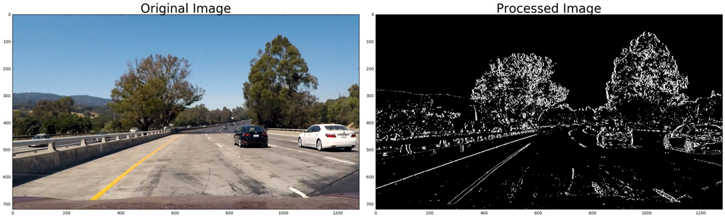

```python
# process all test images and store output
# Make a list of test images
images = glob.glob('test_images/*.jpg')

# Step through the list and undistort the images
for idx, fname in enumerate(images):
    img = mpimg.imread(fname)
    undist = undistort(img, mtx, dist)
    result = threshold(undist)
    mpimg.imsave('output_images/undist_thresh_'+fname[12:],result, cmap='gray')
    if fname[12:] == 'test1.jpg':
        visualize(img, result, bgr_type = False, dst_is_gray=True)
```

### Rubric Item 4 - Perspective Transform

#### Now we do perspective transform

This step involed taking a test image which had straight lines. Indentifying 4 points on undistored image which lie on the lane and then transofrming them to a perspective where the bounded region appears as a rectnagle to provide a top down view. The points were chosen using one of the images with straight lane lines.

The undistored image with 4 points and the perspective of undistored image with 4 points is shown below to check the sanity. Also shown is the perspective transform of the thresholded image.

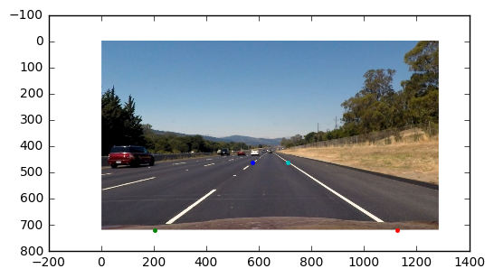

```python
%matplotlib inline
img = mpimg.imread('output_images/undist_straight_lines2.jpg')
#print (img.shape)
plt.imshow(img)

plt.plot(576,460,'.') # top left
plt.plot(203, 719, '.') # bottom left
plt.plot(1127, 719, '.') # bottom right
plt.plot(710, 460, '.') # top right
```

#### The result of Perspective transform on the image used for creating the transform Matrix is shown below

[figure not shown]

#### Process all images store the result of pipeline undistort->threshold->Perspective

All the original images are taken and procssed using pipeline: undistort -> threshold -> perspective Xform. The results are stored as `./output_images/warped_*.jpg`

### Rubric Item 5 - Isolating lines using sliding window

#### Now move on to Locating lines

In this stage, we use the concept of sliding window as explained in the lectures. We first find intial lane centers by doing a histogram of perspecctive image (only the bottom half). We then find the peaks in histogram on the left half and right half. We use these as starting points and then use a sliding window of size 100(i.e. sieze of 50 on each side of center) and a window height of 60. For all the detected pixels in this window, average of x corodinates of all pixels are found and used as x-center of sliding window for next iteration. The idea is the remove all the non lane pixels from the image.

A sample image is show below

[figure not shown]

#### Process all images store the result of pipeline undistort->threshold->Perspective->isolate Lines

We now run the complete pipeline: `undistort->threshold->Perspective Xform ->isolate lines` on all the test images. Processed images form this pipeline are again stored in the output folder as `./output_images/only_lanes_*.jpg`

### Rubric item 6 - Curve Fitting

#### Next step is to fit the Right and Left Lines

After the lanes have been isolated in the Perspecive image. A second degree polynomial is fitted to estimate the lane boundary and use this fitted lane edges to color the lane in subsequent pipelines.

A sample image with curve fitting is shown below

[figure not shown]

#### Final Pipeline: Undistort -> threshold -> perspective -> Isolate lines -> fit lane lines -> Reverse Perspective with Lane and other data superimposed

Now the pipeline is ready. We do following additions a) We used the fitted lane lines to find the radius of curvature of left and right lines. Also the offset of vehicle from center of the lane. This data is superimposed on the image. b) We also color the region between the lane line in green in the perspective image and then tarnsform it back from top down to regualr review using `Minv` - i.e. inverse transform. The result then is the un distored image with identified lane segment colored in green as well as suerimposed data of radius of curvature and lane position.

THe above pipeline suffices for single images. However, for processing video file, we use an object `Line` - one for right and left lane each. As we fit 2-degree curve, we store various parmaters such as estimated lane points - last n detections as well as average, estimated coefficients - last and average over last n and such some more data.

FOr each frame, if the fit was good in previous frame, we use the starting point of lanes from previous frame to start the sliding window. In case the fit in previous several frames was not good, we then assume that we have lost tracking of the lane and us histogram technique to once agin find the start of lane.

We also use smoothening of coefficients to avoid jumps in the lane during video processing.

The pipeline below combines two more fucntionality - a) flag to control plotting of each step in pipeline `plot_result` flag, and b) to skip tracking for individual images vs use of tracking for video processing `video_clip` flag.

#### Run full pipeline on all test images

The complete pipeline is run over the test images and result is stored as `./output_images/final_output*.jpg`

Plots are shown for one of the sample images as procssed through various stages of pipeline is show below

[figure not shown]

#### A sample of image with annotations of curvature and offset is shown below

[figure not shown]

### Rubric Item 7 - Porcecssing a video with above pipeline and tracking

### Now Try on Video with tracker of recent measurements and recovery capabilities

We now run the above pipeline `(undistort->threshold->perspectiveXform->isolate_lines->fit_lines->color_Lane->reverse perspective->merge curvature and position data)` along with tracking capability on the video.

```python
# Import everything needed to edit/save/watch video clips
from moviepy.editor import VideoFileClip
from IPython.display import HTML
```

```python
HTML("""
<video width="960" height="540" controls>
  <source src="{0}">
</video>
""".format('project_video_output.mp4'))
```

[video not shown]

### Rubric Item 8 - Reflections on areas of Improvement

The video under full pipeline runs well on the simple Project Video. It took me mnay iterations to get here. Some of the challenges I faced and areas of improvement are listed below:

**a) Finding a good image for perspetive transform:** Original test images supplied with the project did not have good exmample of straight lines. So I used `cv2.get_frame` to locate a good image and stored it as `test7.jpg`. I used undistored version of this image for the perspective matrix calculation. Later udacity provided two good examples of straight lane image. I then switched to `straight_lines2.jpg` for calibration.

**b) Locating the coordinate of trapizoid:** Even with a good image, it was not easy to locate accurtely the coordinates of 4 points on undistorted image and the corresponding coordinates in the bird's-eye view (top_down view). This turned out to be the area where I spent considerable time.

**c) Sliding window implementation:**It took me a while to get the algorithm going for sliding window. Working with (x,y) coordinates wherein numpy's first axis is y and 2nd axis is x created considerable confusion to map the physical image coordinates back and forth to the way numpy array of image is stored. The sliding window needs more improvement esp when the lanes curve a lot. Histogram technique to locate the start can fail in case of lanes that curve a lot in the perspetive image. This needs to be improved a lot esp. by combining the past detection from prior frames.

**d) Lane tracking:** This is still work in progress. I am not at all satisfied with the way I am storing and using this data for making corrections to lane estimates. My approach is still very crude and needs to be refined a lot to make it work esp on road when lanes curve a lot. The shortfall is demonstarted by the poor quality of result on challeneg videos.

**e) Thresholding:** Thresholding can be improved further to isolate lanes from rest of the image. I did not spend a whole lot of time trying more than basic techniques.

#### Running the above pipeline on Challenge Video One

```python
HTML("""
<video width="960" height="540" controls>
  <source src="{0}">
</video>
""".format('challenge_video_output.mp4'))
```

[video not shown]

#### Analysis of above result

As we can see, the pipeline fails esp on the left side. That is due to an dark colored break in road just inside left lane. This edge is mixed with the left lane edge and forces the poly_fit to find optimial fit considering both the edge points - i.e. left lane points and broken road.

#### Running the above pipeline on Harder Challenge Video

```python
HTML("""
<video width="960" height="540" controls>
  <source src="{0}">
</video>
""".format('harder_challenge_video_output.mp4'))
```

[video not shown]

#### Analysis of Output above

Current pipeline completely fails on the harder challenge video. It shows the weakness of my pipeline as predicted above that it will fail on roads where lanes curve a lot or where there are other edges all over the road making isolation of lane pixels from others very tough.

Something to look into in future in my spare time.